# Weather in the United States (1996-2023)

Andrew Morris

2025-03-17

```r
library(tidyverse)
library(tidymodels)
library(janitor)
library(workflows)
library(parsnip)
library(tidyclust)
library(usmap)
library(gghighlight)
library(knitr)
library(xaringanExtra)
library(doParallel)
library(broom)
library(patchwork)

xaringanExtra::use_panelset()
```

# Research Question

How have storm events changed over time, and what are the personal and monetary effects of these changes?

We chose to investigate this question due to the increasingly dramatic shifts in climate observed in recent years. Many of these changes seem to be significantly impacting the United States, and we wanted to explore those impacts in our data.

# Data

Our data was sourced from the Storm Events Database of the National Oceanic and Atmospheric Administration (NOAA). Individual .csv files were downloaded and compiled using the script found in `data/compile_script`. The NOAA collects data on weather events in the United States. This includes information on event location, 50 variables related to event details (including, notably, time of occurrence and damages), and 10 variables related to event fatalities. In our analysis, we focused on over 1.6 million observations collected between 1996 and 2023.

In our initial cleaning, we notably removed unwanted variables such as event narrative (a multi-sentence description of the event), merged date columns and converted them to date-times with `lubridate`, and added a column for total damage cost (summing crop and property damage). All damage information was converted from a string to a double. The cleaning script can be found in it’s entirety below.

# Load Data

```r
details = read_csv('data/original_data/details_combined.csv')
fatalities = read_csv('data/original_data/fatalities_combined.csv')
```

# Clean Data

```r
# Merge and convert formats of begin-date variables
details <- details %>%
  # Combine date elements
  unite("BEGIN_DATE", BEGIN_YEARMONTH, BEGIN_DAY, sep = "") %>%
  mutate(
    # Convert date to a character for union with time
    BEGIN_DATE = as.character(BEGIN_DATE),
    # Add leading zero if the time is 3 digits
    BEGIN_TIME = case_when(
      BEGIN_TIME < 1000 ~ sprintf("%04d", BEGIN_TIME),
      TRUE ~ as.character(BEGIN_TIME)
    )
  ) %>%
  # Unite date and time into one string
  unite("BEGIN_DT", BEGIN_DATE, BEGIN_TIME, sep = " ") %>%
  mutate(
    # Convert to a datetime
    BEGIN_DT = ymd_hm(BEGIN_DT)
  )

# Merge and convert formats of end-date variables
details <- details %>%
  # Combine date elements
  unite("END_DATE", END_YEARMONTH, END_DAY, sep = "") %>%
  mutate(
    # Convert date to a character for union with time
    END_DATE = as.character(END_DATE),
    # Add leading zero if the time is 3 digits
    END_TIME = case_when(
      END_TIME < 1000 ~ sprintf("%04d", END_TIME),
      TRUE ~ as.character(END_TIME)
    )
  ) %>%
  # Unite date and time into one string
  unite("END_DT", END_DATE, END_TIME, sep = " ") %>%
  mutate(
    # Convert to a datetime
    END_DT = ymd_hm(END_DT)
  )

# Remove unnecessary columns
details <- details %>%
  select(
    -c(YEAR, MONTH_NAME, BEGIN_DATE_TIME, END_DATE_TIME,
       EVENT_NARRATIVE, EPISODE_NARRATIVE
    )
  )

# Rename incorrect column names
details <- details %>%
  rename(
    REGION = STATE,
    REGION_FIPS = STATE_FIPS
  )

# Create duration variable
details <- details %>%
  mutate(
    duration = END_DT - BEGIN_DT
  ) %>%
    mutate(
      duration = as.numeric(duration) / 60
    )

# Change cost suffixes
details <- details %>%
  mutate(
    DAMAGE_PROPERTY = as.numeric(gsub("K", "e+03", gsub("M", "e+06", DAMAGE_PROPERTY))),
    DAMAGE_CROPS = as.numeric(gsub("K", "e+03", gsub("M", "e+06", DAMAGE_CROPS)))
  )

# Create a total damage column using crops and property
details <- details %>%
  mutate(
    DAMAGE_TOTAL = DAMAGE_PROPERTY + DAMAGE_CROPS
  )

# Remove all records pertaining to an incomplete year
details <- details %>%
  filter(
    !year(BEGIN_DT) == '2024'
  )

# Use janitor to convert variable names to snakecase
details <- details %>%
  clean_names()

# Tidy the fatalities DataFrame
fatalities <- fatalities %>%
  select(
    -FAT_TIME, -FATALITY_DATE, -EVENT_YEARMONTH
  ) %>%
    mutate(
      YMD = ymd(paste(FAT_YEARMONTH, FAT_DAY))
    ) %>%
      select(
        -FAT_DAY, -FAT_YEARMONTH
      )

# Remove 2024 records
fatalities <- fatalities %>%
  filter(
    !year(YMD) == '2024'
  )

# Use janitor to convert variables to snakecase
fatalities <- fatalities %>%
  clean_names()

details <- details %>%
  mutate(
    event_type = recode(
      event_type,
      "Hurricane (Typhoon)" = "Hurricane"
    )
  )

#save cleaned data
#write_rds(details, "data/clean_data/details_clean.rds", compress = "gz")
#write_rds(fatalities, "data/clean_data/fatalities_clean.rds")
```

# Load Cleaned Data

```r
setwd("~/Storm-Events-Project/")
details = read_rds('data/clean_data/details_clean.rds')
fatalities = read_rds('data/clean_data/fatalities_clean.rds')
```

Regarding the `fatalities` dataset, I was interested in groups that appeared to be underrepresented and disproportionately affected by storm events. I chose to look at those aged 0-13 and 70+ as the groups of interest. To simplify the analysis, I separated our weather events into more general categories.

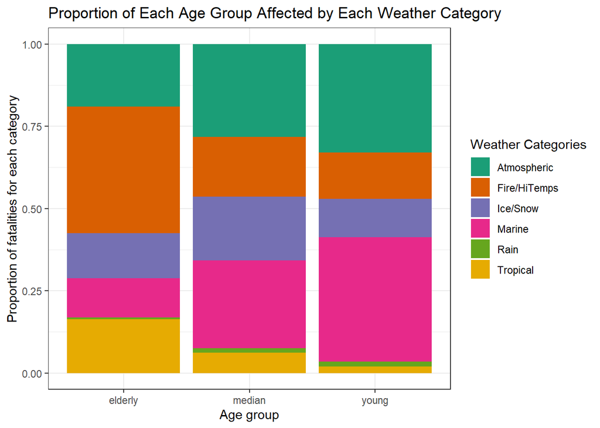

This allows us to see how different age groups are disproportionately affected by different types of weather, giving us a better understanding of who is most vulnerable to storm events. For example, you can see that both `Fire/HiTemps` and `Tropical` events are most dangerous for the elderly group, while `Atmospheric` and `Marine` events are most dangerous for younger individuals.

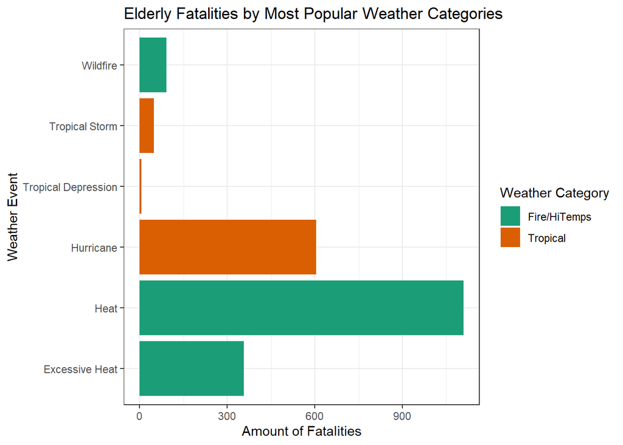

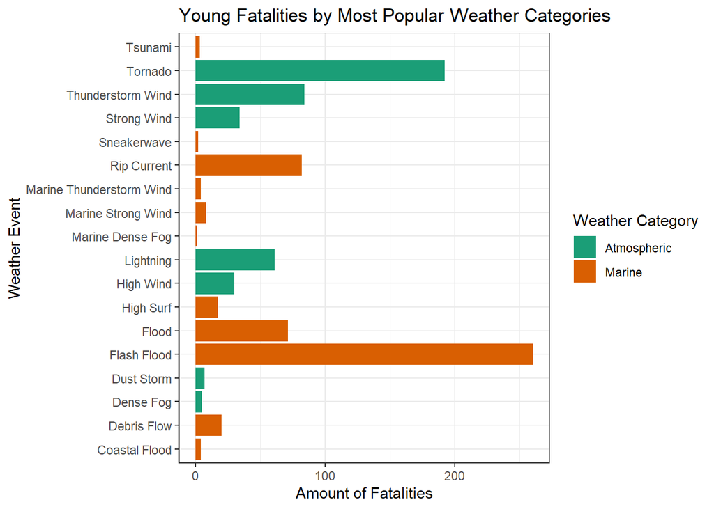

Specifically, I found that the younger age group is most affected by floods and tornadoes, whilst the elderly group is most affected by heat and hurricanes.

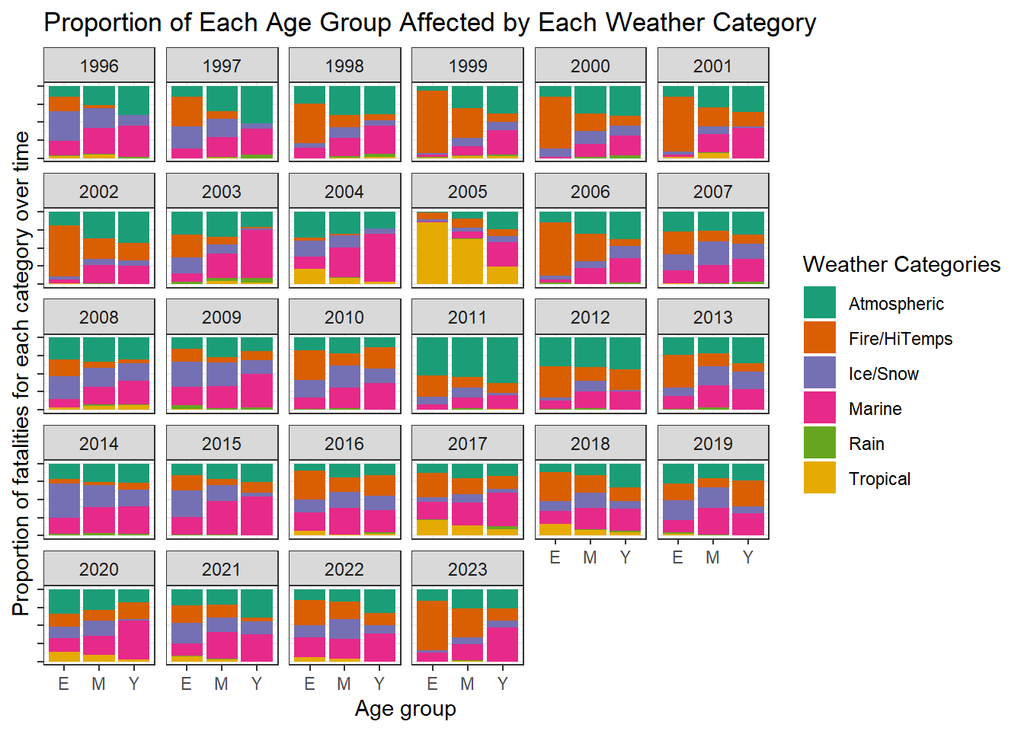

I can also see how these proportions have changed over the years of recorded data, and even note that in years of extraordinary weather (such as Hurricane Katrina in 2005 and a set of major tornadoes in 2011), weather events will continue to disproportionately affect the respective age groups.

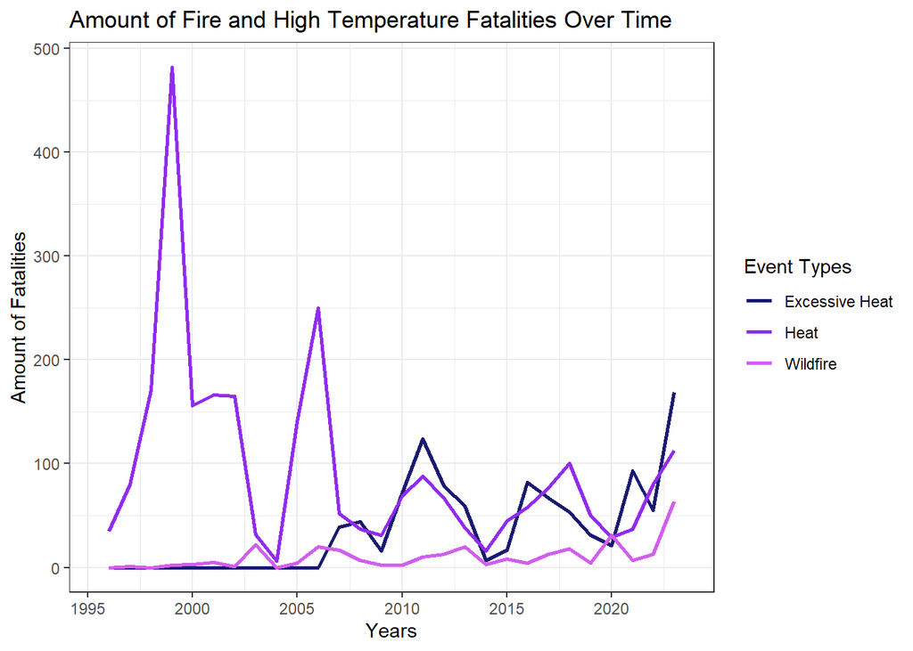

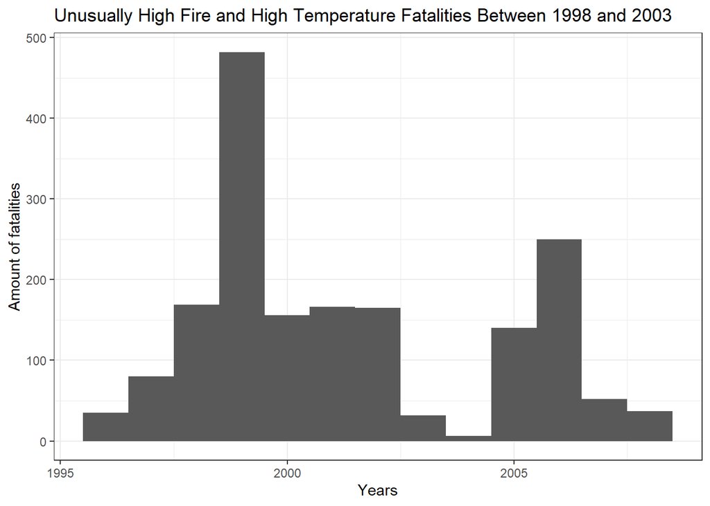

I also found that, over the past 20 years, the fatalities resulting from `Fire/HiTemps` has increased. This could possibly be the result of climate change impacting weather in the United States.

## References

National Oceanic and Atmospheric Administration (2023). *Past Events*. [online] Noaa.gov. Available at: https://psl.noaa.gov/enso/past_events.html [Accessed Nov. 2024].

NOAA Weather service, provided data for the project, accessed at URL: https://www.ncdc.noaa.gov/stormevents/faq.jsp NOAA Weather service, data format guide, accessed at URL: https://www.ncei.noaa.gov/pub/data/swdi/stormevents/csvfiles/Storm-Data-Bulk-csv-Format.pdf